# Data manipulation with tidyr

Use tidyr for data manipulation. tidyr is a package by Hadley Wickham that makes it easy to tidy your data. It is often used in conjunction with dplyr. Data is said to be tidy when each column represents a variable, and each row represents an observation.

Demonstrate the usage of the following four functions from the tidyr package:

- **gather** – converts wide data to longer format. It is analogous to the melt function from reshape2.
- **spread** – converts long data to wider format. It is analogous to the cast function from reshape2.
- **unite** – combines two or more columns into a single column.
- **separate** – splits one column into two or more columns.

I will use the mtcars dataset from the datasets library. If you are not familiar with it, this is what it looks like:

```r
library(tidyr)
library(dplyr)
head(mtcars)
```

```
##                    mpg cyl disp  hp drat    wt  qsec vs am gear carb
## Mazda RX4         21.0   6  160 110 3.90 2.620 16.46  0  1    4    4
## Mazda RX4 Wag     21.0   6  160 110 3.90 2.875 17.02  0  1    4    4
## Datsun 710        22.8   4  108  93 3.85 2.320 18.61  1  1    4    1
## Hornet 4 Drive    21.4   6  258 110 3.08 3.215 19.44  1  0    3    1
## Hornet Sportabout 18.7   8  360 175 3.15 3.440 17.02  0  0    3    2
## Valiant           18.1   6  225 105 2.76 3.460 20.22  1  0    3    1
```

Let us include the names of the cars in a column called car for easier manipulation.

```r
mtcars$car <- rownames(mtcars)
mtcars <- mtcars[, c(12, 1:11)]
head(mtcars)
```

```
##                                 car  mpg cyl disp  hp drat    wt  qsec vs
## Mazda RX4                 Mazda RX4 21.0   6  160 110 3.90 2.620 16.46  0
## Mazda RX4 Wag         Mazda RX4 Wag 21.0   6  160 110 3.90 2.875 17.02  0
## Datsun 710               Datsun 710 22.8   4  108  93 3.85 2.320 18.61  1
## Hornet 4 Drive       Hornet 4 Drive 21.4   6  258 110 3.08 3.215 19.44  1
## Hornet Sportabout Hornet Sportabout 18.7   8  360 175 3.15 3.440 17.02  0
## Valiant                     Valiant 18.1   6  225 105 2.76 3.460 20.22  1
##                   am gear carb
## Mazda RX4          1    4    4
## Mazda RX4 Wag      1    4    4
## Datsun 710         1    4    1
## Hornet 4 Drive     0    3    1
## Hornet Sportabout  0    3    2
## Valiant            0    3    1
```

## gather

gather takes the form (from the help file): gather(data, key, value, …, na.rm = FALSE, convert = FALSE)

where … is the specification of the columns to gather.

We can replicate what melt does as follows:

```r
mtcarsNew <- mtcars %>% gather(attribute, value, -car)
head(mtcarsNew)
```

```
##                 car attribute value
## 1         Mazda RX4       mpg  21.0
## 2     Mazda RX4 Wag       mpg  21.0
## 3        Datsun 710       mpg  22.8
## 4    Hornet 4 Drive       mpg  21.4
## 5 Hornet Sportabout       mpg  18.7
## 6           Valiant       mpg  18.1
```

```r
tail(mtcarsNew)
```

```
##                car attribute value
## 347  Porsche 914-2      carb     2
## 348   Lotus Europa      carb     2
## 349 Ford Pantera L      carb     4
## 350   Ferrari Dino      carb     6
## 351  Maserati Bora      carb     8
## 352     Volvo 142E      carb     2
```

As you can see, it gathers all the columns except car and places their name and value into the attritube and value column respectively.

The great thing about tidyr is that you can gather only certain columns and leave the others alone. If we want to gather all the columns from mpg to gear and leave the carb and car columns as they are, we can do it as follows:

```r
mtcarsNew <- mtcars %>% gather(attribute, value, mpg:gear)
head(mtcarsNew)
```

```
##                 car carb attribute value
## 1         Mazda RX4    4       mpg  21.0
## 2     Mazda RX4 Wag    4       mpg  21.0
## 3        Datsun 710    1       mpg  22.8
## 4    Hornet 4 Drive    1       mpg  21.4
## 5 Hornet Sportabout    2       mpg  18.7
## 6           Valiant    1       mpg  18.1
```

## spread

spread takes the form(from the help file): spread(data, key, value, fill = NA, convert = FALSE, drop = TRUE)

We can replicate what cast does as follows:

```r
mtcarsSpread <- mtcarsNew %>% spread(attribute, value)
head(mtcarsSpread)
```

```
##                  car carb am cyl disp drat gear  hp  mpg  qsec vs    wt
## 1        AMC Javelin    2  0   8  304 3.15    3 150 15.2 17.30  0 3.435
## 2 Cadillac Fleetwood    4  0   8  472 2.93    3 205 10.4 17.98  0 5.250
## 3         Camaro Z28    4  0   8  350 3.73    3 245 13.3 15.41  0 3.840
## 4  Chrysler Imperial    4  0   8  440 3.23    3 230 14.7 17.42  0 5.345
## 5         Datsun 710    1  1   4  108 3.85    4  93 22.8 18.61  1 2.320
## 6   Dodge Challenger    2  0   8  318 2.76    3 150 15.5 16.87  0 3.520
```

## unite

unite takes the form (from the help file): unite(data, col, …, sep = “_“, remove = TRUE)

where … represents the columns to unite and col represents the column to add.

Let us create some fake data:

```r
set.seed(1)
date <- as.Date('2016-01-01') + 0:14
hour <- sample(1:24, 15)
min <- sample(1:60, 15)
second <- sample(1:60, 15)
event <- sample(letters, 15)
data <- data.frame(date, hour, min, second, event)
data
```

```
##          date hour min second event
## 1  2016-01-01    7  30     29     u
## 2  2016-01-02    9  43     36     a
## 3  2016-01-03   13  58     60     l
## 4  2016-01-04   20  22     11     q
## 5  2016-01-05    5  44     47     p
## 6  2016-01-06   18  52     37     k
## 7  2016-01-07   19  12     43     r
## 8  2016-01-08   12  35      6     i
## 9  2016-01-09   11   7     38     e
## 10 2016-01-10    1  14     21     b
## 11 2016-01-11    3  20     42     w
## 12 2016-01-12   14   1     32     t
## 13 2016-01-13   23  19     52     h
## 14 2016-01-14   21  41     26     s
## 15 2016-01-15    8  16     25     o
```

Now, let us combine the date, hour, min, and second columns into a new column called datetime. Usually, datetime in R is of the form Year-Month-Day Hour:Min:Second.

```r
dataNew <- data %>%
  unite(datehour, date, hour, sep = ' ') %>%
  unite(datetime, datehour, min, second, sep = ':')
dataNew
```

```
##               datetime event
## 1   2016-01-01 7:30:29     u
## 2   2016-01-02 9:43:36     a
## 3  2016-01-03 13:58:60     l
## 4  2016-01-04 20:22:11     q
## 5   2016-01-05 5:44:47     p
## 6  2016-01-06 18:52:37     k
## 7  2016-01-07 19:12:43     r
## 8   2016-01-08 12:35:6     i
## 9   2016-01-09 11:7:38     e
## 10  2016-01-10 1:14:21     b
## 11  2016-01-11 3:20:42     w
## 12  2016-01-12 14:1:32     t
## 13 2016-01-13 23:19:52     h
## 14 2016-01-14 21:41:26     s
## 15  2016-01-15 8:16:25     o
```

## separate

separate takes the form (from the help file): separate(data, col, into, sep = “[^[:alnum:]]+”, remove = TRUE, convert = FALSE, extra = “warn”, fill = “warn”, …)

We can get back the original data we created using separate as follows:

```r
data1 <- dataNew %>%
  separate(datetime, c('date', 'time'), sep = ' ') %>%
  separate(time, c('hour', 'min', 'second'), sep = ':')
data1
```

```
##          date hour min second event
## 1  2016-01-01    7  30     29     u
## 2  2016-01-02    9  43     36     a
## 3  2016-01-03   13  58     60     l
## 4  2016-01-04   20  22     11     q
## 5  2016-01-05    5  44     47     p
## 6  2016-01-06   18  52     37     k
## 7  2016-01-07   19  12     43     r
## 8  2016-01-08   12  35      6     i
## 9  2016-01-09   11   7     38     e
## 10 2016-01-10    1  14     21     b
## 11 2016-01-11    3  20     42     w
## 12 2016-01-12   14   1     32     t
## 13 2016-01-13   23  19     52     h
## 14 2016-01-14   21  41     26     s
## 15 2016-01-15    8  16     25     o
```

It first splits the datetime column into date and time, and then splits time into hour, min, and second.

## tidyr Update

tidyr 0.4.0. makes it easy to “tidy” your data, storing it in a consistent form so that it’s easy to manipulate, visualise and model. Tidy data has a simple convention: put variables in the columns and observations in the rows. You can learn more about it in the tidy data vignette. Install it with: install.packages(“tidyr”)

There are two big features in this release: support for **nested data frames**, and improved tools for **turning implicit missing values into explicit missing values**. These are described in detail below. As well as these big features, all tidyr verbs now handle grouped_df objects created by dplyr, gather() makes a character key column (instead of a factor), and there are lots of other minor fixes and improvements. Please see the release notes for a complete list of changes.

### Nested data frames

nest() and unnest() have been overhauled to support a new way of structuring your data: the nested data frame. In a grouped data frame, you have one row per observation, and additional metadata define the groups. In a nested data frame, you have one row per group, and the individual observations are stored in a column that is a list of data frames. This is a useful structure when you have lists of other objects (like models) with one element per group.

For example, take the gapminder dataset:

```r
library(gapminder)
library(dplyr)

gapminder
```

```
## Source: local data frame [1,704 x 6]
##
##        country continent  year lifeExp      pop gdpPercap
##         (fctr)    (fctr) (int)   (dbl)    (int)     (dbl)
## 1  Afghanistan      Asia  1952  28.801  8425333  779.4453
## 2  Afghanistan      Asia  1957  30.332  9240934  820.8530
## 3  Afghanistan      Asia  1962  31.997 10267083  853.1007
## 4  Afghanistan      Asia  1967  34.020 11537966  836.1971
## 5  Afghanistan      Asia  1972  36.088 13079460  739.9811
## 6  Afghanistan      Asia  1977  38.438 14880372  786.1134
## 7  Afghanistan      Asia  1982  39.854 12881816  978.0114
## 8  Afghanistan      Asia  1987  40.822 13867957  852.3959
## 9  Afghanistan      Asia  1992  41.674 16317921  649.3414
## 10 Afghanistan      Asia  1997  41.763 22227415  635.3414
## ..         ...       ...   ...     ...      ...       ...
```

We can plot the trend in life expetancy for each country:

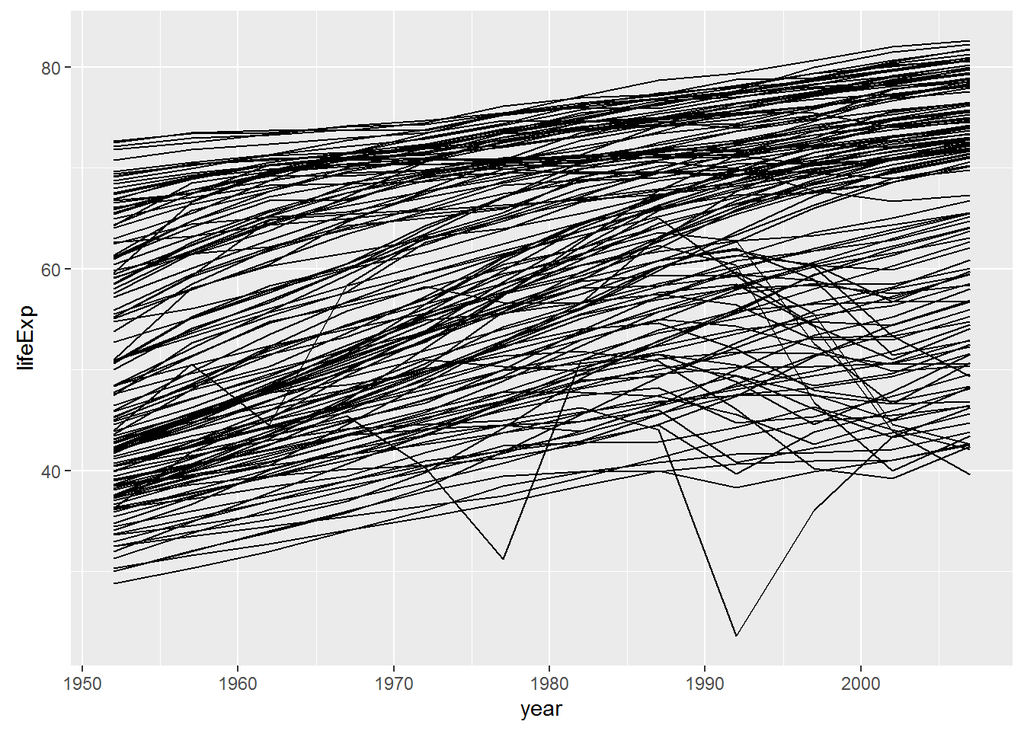

```r
library(ggplot2)

ggplot(gapminder, aes(year, lifeExp)) +
  geom_line(aes(group = country))
```

But it’s hard to see what’s going on because of all the overplotting. One interesting solution is to summarise each country with a linear model. To do that most naturally, you want one data frame for each country. nest() creates this structure:

```r
by_country <- gapminder %>%
  group_by(continent, country) %>%
  nest()

by_country
```

```
## Source: local data frame [142 x 3]
##
##    continent     country            data
##       (fctr)      (fctr)           (chr)
## 1       Asia Afghanistan <tbl_df [12,4]>
## 2     Europe     Albania <tbl_df [12,4]>
## 3     Africa     Algeria <tbl_df [12,4]>
## 4     Africa      Angola <tbl_df [12,4]>
## 5   Americas   Argentina <tbl_df [12,4]>
## 6    Oceania   Australia <tbl_df [12,4]>
## 7     Europe     Austria <tbl_df [12,4]>
## 8       Asia     Bahrain <tbl_df [12,4]>
## 9       Asia  Bangladesh <tbl_df [12,4]>
## 10    Europe     Belgium <tbl_df [12,4]>
## ..       ...         ...             ...
```

```r
by_country$data[[1]]
```

```
## Source: local data frame [12 x 4]
##
##     year lifeExp      pop gdpPercap
##    (int)   (dbl)    (int)     (dbl)
## 1   1952  43.077  9279525  2449.008
## 2   1957  45.685 10270856  3013.976
## 3   1962  48.303 11000948  2550.817
## 4   1967  51.407 12760499  3246.992
## 5   1972  54.518 14760787  4182.664
## 6   1977  58.014 17152804  4910.417
## 7   1982  61.368 20033753  5745.160
## 8   1987  65.799 23254956  5681.359
## 9   1992  67.744 26298373  5023.217
## 10  1997  69.152 29072015  4797.295
## 11  2002  70.994 31287142  5288.040
## 12  2007  72.301 33333216  6223.367
```

This form is natural because there are other vectors where you’ll have one value per country. For example, we could fit a linear model to each country with purrr:

```r
by_country <- by_country %>%
  mutate(model = purrr::map(data, ~ lm(lifeExp ~ year, data = .))
)
by_country
```

```
## Source: local data frame [142 x 4]
##
##    continent     country            data   model
##       (fctr)      (fctr)           (chr)   (chr)
## 1       Asia Afghanistan <tbl_df [12,4]> <S3:lm>
## 2     Europe     Albania <tbl_df [12,4]> <S3:lm>
## 3     Africa     Algeria <tbl_df [12,4]> <S3:lm>
## 4     Africa      Angola <tbl_df [12,4]> <S3:lm>
## 5   Americas   Argentina <tbl_df [12,4]> <S3:lm>
## 6    Oceania   Australia <tbl_df [12,4]> <S3:lm>
## 7     Europe     Austria <tbl_df [12,4]> <S3:lm>
## 8       Asia     Bahrain <tbl_df [12,4]> <S3:lm>
## 9       Asia  Bangladesh <tbl_df [12,4]> <S3:lm>
## 10    Europe     Belgium <tbl_df [12,4]> <S3:lm>
## ..       ...         ...             ...     ...
```

Because we used mutate(), we get an extra column containing one linear model per country.

It might seem unnatural to store a list of linear models in a data frame. However, I think it is actually a really convenient and powerful strategy because it allows you to keep related vectors together. If you filter or arrange the vector of models, there’s no way for the other components to get out of sync.

nest() got us into this form; unnest() gets us out. You give it the list-columns that you want to unnested, and tidyr will automatically repeat the grouping columns. Unnesting data gets us back to the original form:

```r
by_country %>% unnest(data)
```

```
## Source: local data frame [1,704 x 6]
##
##    continent     country  year lifeExp      pop gdpPercap
##       (fctr)      (fctr) (int)   (dbl)    (int)     (dbl)
## 1       Asia Afghanistan  1952  43.077  9279525  2449.008
## 2       Asia Afghanistan  1957  45.685 10270856  3013.976
## 3       Asia Afghanistan  1962  48.303 11000948  2550.817
## 4       Asia Afghanistan  1967  51.407 12760499  3246.992
## 5       Asia Afghanistan  1972  54.518 14760787  4182.664
## 6       Asia Afghanistan  1977  58.014 17152804  4910.417
## 7       Asia Afghanistan  1982  61.368 20033753  5745.160
## 8       Asia Afghanistan  1987  65.799 23254956  5681.359
## 9       Asia Afghanistan  1992  67.744 26298373  5023.217
## 10      Asia Afghanistan  1997  69.152 29072015  4797.295
## ..       ...         ...   ...     ...      ...       ...
```

When working with models, unnesting is particularly useful when you combine it with broom to extract model summaries:

```r
# Extract model summaries:
by_country %>% unnest(model %>% purrr::map(broom::glance))
```

```
## Source: local data frame [142 x 15]
##
##    continent     country            data   model r.squared adj.r.squared
##       (fctr)      (fctr)           (chr)   (chr)     (dbl)         (dbl)
## 1       Asia Afghanistan <tbl_df [12,4]> <S3:lm> 0.9851172    0.98362893
## 2     Europe     Albania <tbl_df [12,4]> <S3:lm> 0.8878146    0.87659609
## 3     Africa     Algeria <tbl_df [12,4]> <S3:lm> 0.9666020    0.96326219
## 4     Africa      Angola <tbl_df [12,4]> <S3:lm> 0.0340234   -0.06257426
## 5   Americas   Argentina <tbl_df [12,4]> <S3:lm> 0.9187105    0.91058155
## 6    Oceania   Australia <tbl_df [12,4]> <S3:lm> 0.7659960    0.74259557
## 7     Europe     Austria <tbl_df [12,4]> <S3:lm> 0.6801784    0.64819623
## 8       Asia     Bahrain <tbl_df [12,4]> <S3:lm> 0.4932445    0.44256893
## 9       Asia  Bangladesh <tbl_df [12,4]> <S3:lm> 0.8723755    0.85961305
## 10    Europe     Belgium <tbl_df [12,4]> <S3:lm> 0.9968508    0.99653584
## ..       ...         ...             ...     ...       ...           ...
## Variables not shown: sigma (dbl), statistic (dbl), p.value (dbl), df
##   (int), logLik (dbl), AIC (dbl), BIC (dbl), deviance (dbl), df.residual
##   (int)
```

```r
# Extract coefficients:
by_country %>% unnest(model %>% purrr::map(broom::tidy))
```

```
## Source: local data frame [284 x 7]
##
##    continent     country        term      estimate    std.error
##       (fctr)      (fctr)       (chr)         (dbl)        (dbl)
## 1       Asia Afghanistan (Intercept) -1.067859e+03  43.80220084
## 2       Asia Afghanistan        year  5.692797e-01   0.02212707
## 3     Europe     Albania (Intercept) -3.765048e+02  46.58337060
## 4     Europe     Albania        year  2.093399e-01   0.02353200
## 5     Africa     Algeria (Intercept) -6.128340e+02  38.89176269
## 6     Africa     Algeria        year  3.342329e-01   0.01964652
## 7     Africa      Angola (Intercept) -6.549586e+01 202.36245423
## 8     Africa      Angola        year  6.066853e-02   0.10222519
## 9   Americas   Argentina (Intercept) -6.757942e+02  67.77526825
## 10  Americas   Argentina        year  3.639748e-01   0.03423728
## ..       ...         ...         ...           ...          ...
## Variables not shown: statistic (dbl), p.value (dbl)
```

```r
# Extract residuals etc:
by_country %>% unnest(model %>% purrr::map(broom::augment))
```

```
## Source: local data frame [1,704 x 11]
##
##    continent     country lifeExp  year  .fitted   .se.fit     .resid
##       (fctr)      (fctr)   (dbl) (int)    (dbl)     (dbl)      (dbl)
## 1       Asia Afghanistan  43.077  1952 43.37497 0.7184202 -0.2979744
## 2       Asia Afghanistan  45.685  1957 46.22137 0.6274758 -0.5363730
## 3       Asia Afghanistan  48.303  1962 49.06777 0.5438790 -0.7647716
## 4       Asia Afghanistan  51.407  1967 51.91417 0.4715541 -0.5071702
## 5       Asia Afghanistan  54.518  1972 54.76057 0.4164163 -0.2425688
## 6       Asia Afghanistan  58.014  1977 57.60697 0.3859044  0.4070326
## 7       Asia Afghanistan  61.368  1982 60.45337 0.3859044  0.9146340
## 8       Asia Afghanistan  65.799  1987 63.29976 0.4164163  2.4992354
## 9       Asia Afghanistan  67.744  1992 66.14616 0.4715541  1.5978368
## 10      Asia Afghanistan  69.152  1997 68.99256 0.5438790  0.1594382
## ..       ...         ...     ...   ...      ...       ...        ...
## Variables not shown: .hat (dbl), .sigma (dbl), .cooksd (dbl), .std.resid
##   (dbl)
```

I think storing multiple models in a data frame is a powerful and convenient technique, and I plan to write more about it in the future.

### Expanding

The complete() function allows you to turn implicit missing values into explicit missing values. For example, imagine you’ve collected some data every year basis, but unfortunately some of your data has gone missing:

```r
resources <- frame_data(
  ~year, ~metric, ~value,
  1999, "coal", 100,
  2001, "coal", 50,
  2001, "steel", 200
)
resources
```

```
## Source: local data frame [3 x 3]
##
##    year metric value
##   (dbl)  (chr) (dbl)
## 1  1999   coal   100
## 2  2001   coal    50
## 3  2001  steel   200
```

Here the value for steel in 1999 is implicitly missing: it’s simply absent from the data frame. We can use complete() to make this missing row explicit, adding that combination of the variables and inserting a placeholder NA:

```r
resources %>% complete(year, metric)
```

```
## Source: local data frame [4 x 3]
##
##    year metric value
##   (dbl)  (chr) (dbl)
## 1  1999   coal   100
## 2  1999  steel    NA
## 3  2001   coal    50
## 4  2001  steel   200
```

With complete you’re not limited to just combinations that exist in the data. For example, here we know that there should be data for every year, so we can use the fullseq() function to generate every year over the range of the data:

```r
resources %>% complete(year = full_seq(year, 1L), metric)
```

```
## Source: local data frame [6 x 3]
##
##    year metric value
##   (dbl)  (chr) (dbl)
## 1  1999   coal   100
## 2  1999  steel    NA
## 3  2000   coal    NA
## 4  2000  steel    NA
## 5  2001   coal    50
## 6  2001  steel   200
```

In other scenarios, you may not want to generate the full set of combinations. For example, imagine you have an experiment where each person is assigned one treatment. You don’t want to expand the combinations of person and treatment, but you do want to make sure every person has all replicates. You can use nesting() to prevent the full Cartesian product from being generated:

```r
experiment <- data_frame(
  person = rep(c("Alex", "Robert", "Sam"), c(3, 2, 1)),
  trt  = rep(c("a", "b", "a"), c(3, 2, 1)),
  rep = c(1, 2, 3, 1, 2, 1),
  measurment_1 = runif(6),
  measurment_2 = runif(6)
)
experiment
```

```
## Source: local data frame [6 x 5]
##
##   person   trt   rep measurment_1 measurment_2
##    (chr) (chr) (dbl)        (dbl)        (dbl)
## 1   Alex     a     1    0.9128759   0.47854525
## 2   Alex     a     2    0.2936034   0.76631067
## 3   Alex     a     3    0.4590657   0.08424691
## 4 Robert     b     1    0.3323947   0.87532133
## 5 Robert     b     2    0.6508705   0.33907294
## 6    Sam     a     1    0.2580168   0.83944035
```

```r
experiment %>% complete(nesting(person, trt), rep)
```

```
## Source: local data frame [9 x 5]
##
##   person   trt   rep measurment_1 measurment_2
##    (chr) (chr) (dbl)        (dbl)        (dbl)
## 1   Alex     a     1    0.9128759   0.47854525
## 2   Alex     a     2    0.2936034   0.76631067
## 3   Alex     a     3    0.4590657   0.08424691
## 4 Robert     b     1    0.3323947   0.87532133
## 5 Robert     b     2    0.6508705   0.33907294
## 6 Robert     b     3           NA           NA
## 7    Sam     a     1    0.2580168   0.83944035
## 8    Sam     a     2           NA           NA
## 9    Sam     a     3           NA           NA
```